# Manuscript Preparation: Supplementary Material

Jess L. Wild, MS

Alexander M. Kaizer. PhD

04/15/2024

## Tabular Results for Arbitrary Upstrapping (AU)

This section (*Table S1*:*Table S4*) includes tabular results summaries for the arbitrary upstrapping (AU) approach to interim monitoring. For each sample size ($N$) and power ($\beta$) based scenario three evaluation metrics are reported: expected total sample size (*Expected $N$*), proportion of trials that stopped early at any interim stopping point (*Proportion Stopped*), and proportion of trials that either stopped early for efficacy or rejected the null hypothesis with the full sample data (*Proportion Rejected*). All tables also include fixed sample rejection rate results for comparison. *Table S1* reports results for trials designed with a single interim stopping point at 25% of the total sample size. *Table S2* reports results for trials designed with a single interim stopping point at 50% of the total sample size. *Table S3* reports results for trials designed with a single interim stopping point at 75% of the total sample size. *Table S4* reports results for trials designed with sequential interim stopping points at 25%, 50%, and 75% of the total sample size.

**Table S1: Simulation Results Using Arbitrary Upstrapping Thresholds for 0.25 Stopping Point Monitoring**

| N | $\beta$ | *Futility Only Monitoring* Expected N *mean(sd)* | *Futility Only Monitoring* Proportion Stopped | *Futility Only Monitoring* Proportion Rejected | *Efficacy Only Monitoring* Expected N *mean(sd)* | *Efficacy Only Monitoring* Proportion Stopped | *Efficacy Only Monitoring* Proportion Rejected | *Futility and Efficacy Monitoring* Expected N *mean(sd)* | *Futility and Efficacy Monitoring* Proportion Stopped | *Futility and Efficacy Monitoring* Proportion Stopped (Futility) | *Futility and Efficacy Monitoring* Proportion Stopped (Efficacy) | *Futility and Efficacy Monitoring* Proportion Rejected | *Fixed Sample* Proportion Rejected |
| --- | --- | --- | --- | --- | --- | --- | --- | --- | --- | --- | --- | --- | --- |
| 40 | 0.05 | 33 (12.94) | 0.247 | 0.031 | 35 (11.51) | 0.179 | 0.196 | 28 (14.84) | 0.426 | 0.247 | 0.179 | 0.193 | 0.034 |
| 40 | 0.50 | 36 (10.92) | 0.157 | 0.357 | 30 (14.31) | 0.349 | 0.532 | 25 (15.01) | 0.506 | 0.157 | 0.349 | 0.507 | 0.382 |
| 40 | 0.80 | 38 (8.80) | 0.095 | 0.640 | 25 (15.01) | 0.502 | 0.771 | 23 (14.72) | 0.597 | 0.095 | 0.502 | 0.727 | 0.684 |
| 40 | 0.95 | 39 (5.95) | 0.041 | 0.884 | 20 (14.01) | 0.679 | 0.943 | 19 (13.48) | 0.720 | 0.041 | 0.679 | 0.912 | 0.915 |
| 160 | 0.05 | 121 (56.58) | 0.333 | 0.034 | 142 (43.22) | 0.153 | 0.172 | 102 (60.01) | 0.486 | 0.333 | 0.153 | 0.168 | 0.038 |
| 160 | 0.50 | 138 (47.19) | 0.191 | 0.371 | 120 (56.63) | 0.334 | 0.526 | 97 (59.95) | 0.525 | 0.191 | 0.334 | 0.488 | 0.409 |
| 160 | 0.80 | 145 (40.38) | 0.130 | 0.660 | 102 (60.02) | 0.491 | 0.783 | 86 (58.25) | 0.621 | 0.130 | 0.491 | 0.722 | 0.721 |
| 160 | 0.95 | 152 (31.03) | 0.072 | 0.863 | 84 (57.66) | 0.639 | 0.938 | 75 (54.42) | 0.711 | 0.072 | 0.639 | 0.885 | 0.916 |
| 600 | 0.05 | 501 (187.11) | 0.222 | 0.025 | 528 (165.89) | 0.162 | 0.178 | 428 (218.97) | 0.384 | 0.222 | 0.162 | 0.175 | 0.028 |
| 600 | 0.50 | 545 (147.87) | 0.123 | 0.447 | 438 (216.37) | 0.362 | 0.613 | 382 (225.01) | 0.485 | 0.123 | 0.362 | 0.571 | 0.489 |
| 600 | 0.80 | 559 (130.76) | 0.093 | 0.726 | 380 (225.08) | 0.491 | 0.820 | 338 (221.91) | 0.584 | 0.093 | 0.491 | 0.773 | 0.773 |
| 600 | 0.95 | 582 (88.23) | 0.040 | 0.913 | 306 (214.02) | 0.655 | 0.959 | 288 (207.29) | 0.695 | 0.040 | 0.655 | 0.923 | 0.949 |
| 2000 | 0.05 | 1687 (610.20) | 0.209 | 0.039 | 1739 (568.95) | 0.174 | 0.197 | 1426 (729.54) | 0.383 | 0.209 | 0.174 | 0.196 | 0.040 |
| 2000 | 0.50 | 1799 (511.23) | 0.134 | 0.457 | 1459 (720.80) | 0.361 | 0.596 | 1258 (750.34) | 0.495 | 0.134 | 0.361 | 0.561 | 0.492 |
| 2000 | 0.80 | 1886 (397.70) | 0.076 | 0.766 | 1208 (749.20) | 0.528 | 0.859 | 1094 (733.96) | 0.604 | 0.076 | 0.528 | 0.817 | 0.808 |
| 2000 | 0.95 | 1942 (290.54) | 0.039 | 0.932 | 968 (695.31) | 0.688 | 0.969 | 910 (668.59) | 0.727 | 0.039 | 0.688 | 0.941 | 0.960 |

**Table S2: Simulation Results Using Arbitrary Upstrapping Thresholds for 0.50 Stopping Point Monitoring**

| N | $\beta$ | *Futility Only Monitoring* Expected N *mean(sd)* | *Futility Only Monitoring* Proportion Stopped | *Futility Only Monitoring* Proportion Rejected | *Efficacy Only Monitoring* Expected N *mean(sd)* | *Efficacy Only Monitoring* Proportion Stopped | *Efficacy Only Monitoring* Proportion Rejected | *Futility and Efficacy Monitoring* Expected N *mean(sd)* | *Futility and Efficacy Monitoring* Proportion Stopped | *Futility and Efficacy Monitoring* Proportion Stopped (Futility) | *Futility and Efficacy Monitoring* Proportion Stopped (Efficacy) | *Futility and Efficacy Monitoring* Proportion Rejected | *Fixed Sample* Proportion Rejected |
| --- | --- | --- | --- | --- | --- | --- | --- | --- | --- | --- | --- | --- | --- |
| 40 | 0.05 | 29 (9.90) | 0.572 | 0.034 | 39 (4.44) | 0.052 | 0.074 | 28 (9.69) | 0.624 | 0.572 | 0.052 | 0.074 | 0.034 |
| 40 | 0.50 | 35 (8.70) | 0.253 | 0.367 | 34 (9.18) | 0.301 | 0.457 | 29 (9.95) | 0.554 | 0.253 | 0.301 | 0.442 | 0.382 |
| 40 | 0.80 | 39 (5.81) | 0.093 | 0.672 | 30 (10.00) | 0.503 | 0.734 | 29 (9.82) | 0.596 | 0.093 | 0.503 | 0.722 | 0.684 |
| 40 | 0.95 | 40 (3.06) | 0.024 | 0.908 | 26 (8.84) | 0.734 | 0.936 | 25 (8.57) | 0.758 | 0.024 | 0.734 | 0.929 | 0.915 |
| 160 | 0.05 | 121 (40.02) | 0.495 | 0.037 | 156 (18.71) | 0.058 | 0.081 | 116 (39.79) | 0.553 | 0.495 | 0.058 | 0.080 | 0.038 |
| 160 | 0.50 | 143 (33.32) | 0.223 | 0.393 | 136 (36.71) | 0.301 | 0.478 | 119 (39.97) | 0.524 | 0.223 | 0.301 | 0.462 | 0.409 |
| 160 | 0.80 | 152 (24.22) | 0.102 | 0.703 | 118 (39.96) | 0.527 | 0.768 | 110 (38.67) | 0.629 | 0.102 | 0.527 | 0.750 | 0.721 |
| 160 | 0.95 | 158 (14.91) | 0.036 | 0.905 | 101 (35.15) | 0.739 | 0.930 | 98 (33.42) | 0.775 | 0.036 | 0.739 | 0.919 | 0.916 |
| 600 | 0.05 | 456 (149.98) | 0.482 | 0.024 | 586 (64.79) | 0.049 | 0.069 | 441 (149.79) | 0.531 | 0.482 | 0.049 | 0.065 | 0.028 |
| 600 | 0.50 | 550 (112.48) | 0.169 | 0.464 | 501 (141.24) | 0.331 | 0.549 | 450 (150.08) | 0.500 | 0.169 | 0.331 | 0.524 | 0.489 |
| 600 | 0.80 | 571 (89.24) | 0.098 | 0.748 | 435 (149.29) | 0.551 | 0.797 | 406 (143.26) | 0.649 | 0.098 | 0.551 | 0.772 | 0.773 |
| 600 | 0.95 | 595 (40.98) | 0.019 | 0.937 | 373 (128.37) | 0.759 | 0.959 | 367 (124.74) | 0.778 | 0.019 | 0.759 | 0.947 | 0.949 |
| 2000 | 0.05 | 1555 (497.21) | 0.445 | 0.036 | 1940 (237.61) | 0.060 | 0.084 | 1495 (500.23) | 0.505 | 0.445 | 0.060 | 0.080 | 0.040 |
| 2000 | 0.50 | 1822 (382.70) | 0.178 | 0.480 | 1660 (473.95) | 0.340 | 0.555 | 1482 (499.93) | 0.518 | 0.178 | 0.340 | 0.543 | 0.492 |
| 2000 | 0.80 | 1929 (256.95) | 0.071 | 0.779 | 1444 (497.10) | 0.556 | 0.842 | 1373 (483.84) | 0.627 | 0.071 | 0.556 | 0.813 | 0.808 |
| 2000 | 0.95 | 1983 (129.34) | 0.017 | 0.950 | 1225 (417.79) | 0.775 | 0.966 | 1208 (406.08) | 0.792 | 0.017 | 0.775 | 0.956 | 0.960 |

**Table S3: Simulation Results Using Arbitrary Upstrapping Thresholds for 0.75 Stopping Point Monitoring**

| N | $\beta$ | *Futility Only Monitoring* Expected N *mean(sd)* | *Futility Only Monitoring* Proportion Stopped | *Futility Only Monitoring* Proportion Rejected | *Efficacy Only Monitoring* Expected N *mean(sd)* | *Efficacy Only Monitoring* Proportion Stopped | *Efficacy Only Monitoring* Proportion Rejected | *Futility and Efficacy Monitoring* Expected N *mean(sd)* | *Futility and Efficacy Monitoring* Proportion Stopped | *Futility and Efficacy Monitoring* Proportion Stopped (Futility) | *Futility and Efficacy Monitoring* Proportion Stopped (Efficacy) | *Futility and Efficacy Monitoring* Proportion Rejected | *Fixed Sample* Proportion Rejected |
| --- | --- | --- | --- | --- | --- | --- | --- | --- | --- | --- | --- | --- | --- |
| 40 | 0.05 | 33 (4.10) | 0.786 | 0.034 | 40 (1.62) | 0.027 | 0.046 | 32 (3.90) | 0.813 | 0.786 | 0.027 | 0.046 | 0.034 |
| 40 | 0.50 | 37 (4.63) | 0.311 | 0.382 | 38 (4.43) | 0.268 | 0.410 | 35 (4.94) | 0.579 | 0.311 | 0.268 | 0.410 | 0.382 |
| 40 | 0.80 | 39 (3.04) | 0.103 | 0.679 | 35 (4.99) | 0.538 | 0.710 | 34 (4.80) | 0.641 | 0.103 | 0.538 | 0.705 | 0.684 |
| 40 | 0.95 | 40 (1.59) | 0.026 | 0.911 | 32 (3.87) | 0.817 | 0.927 | 32 (3.64) | 0.843 | 0.026 | 0.817 | 0.923 | 0.915 |
| 160 | 0.05 | 131 (17.40) | 0.747 | 0.036 | 159 (7.35) | 0.035 | 0.053 | 129 (16.52) | 0.782 | 0.747 | 0.035 | 0.051 | 0.038 |
| 160 | 0.50 | 148 (18.62) | 0.317 | 0.401 | 149 (17.91) | 0.277 | 0.441 | 137 (19.65) | 0.594 | 0.317 | 0.277 | 0.433 | 0.409 |
| 160 | 0.80 | 156 (12.96) | 0.119 | 0.717 | 138 (19.88) | 0.557 | 0.742 | 133 (18.73) | 0.676 | 0.119 | 0.557 | 0.738 | 0.721 |
| 160 | 0.95 | 159 (6.37) | 0.026 | 0.913 | 129 (16.39) | 0.787 | 0.925 | 128 (15.60) | 0.813 | 0.026 | 0.787 | 0.922 | 0.916 |
| 600 | 0.05 | 495 (68.64) | 0.702 | 0.027 | 597 (23.43) | 0.025 | 0.044 | 491 (66.86) | 0.727 | 0.702 | 0.025 | 0.043 | 0.028 |
| 600 | 0.50 | 564 (64.28) | 0.242 | 0.478 | 546 (72.08) | 0.361 | 0.522 | 510 (73.43) | 0.603 | 0.242 | 0.361 | 0.511 | 0.489 |
| 600 | 0.80 | 589 (40.48) | 0.079 | 0.768 | 506 (72.50) | 0.629 | 0.788 | 494 (68.24) | 0.708 | 0.079 | 0.629 | 0.783 | 0.773 |
| 600 | 0.95 | 598 (17.63) | 0.014 | 0.944 | 474 (54.17) | 0.846 | 0.956 | 471 (52.07) | 0.860 | 0.014 | 0.846 | 0.951 | 0.949 |
| 2000 | 0.05 | 1645 (226.76) | 0.711 | 0.039 | 1984 (88.04) | 0.032 | 0.058 | 1629 (218.60) | 0.743 | 0.711 | 0.032 | 0.057 | 0.040 |
| 2000 | 0.50 | 1890 (207.23) | 0.220 | 0.486 | 1819 (240.41) | 0.362 | 0.521 | 1709 (246.74) | 0.582 | 0.220 | 0.362 | 0.515 | 0.492 |
| 2000 | 0.80 | 1967 (125.07) | 0.067 | 0.801 | 1671 (237.14) | 0.659 | 0.830 | 1637 (223.12) | 0.726 | 0.067 | 0.659 | 0.823 | 0.808 |
| 2000 | 0.95 | 1995 (49.77) | 0.010 | 0.959 | 1569 (172.01) | 0.863 | 0.963 | 1564 (166.57) | 0.873 | 0.010 | 0.863 | 0.962 | 0.960 |

**Table S4: Simulation Results Using Arbitrary Upstrapping Thresholds for Sequential Monitoring**

| N | $\beta$ | *Futility Only Monitoring* Expected N *mean(sd)* | *Futility Only Monitoring* Proportion Stopped | *Futility Only Monitoring* Proportion Rejected | *Efficacy Only Monitoring* Expected N *mean(sd)* | *Efficacy Only Monitoring* Proportion Stopped | *Efficacy Only Monitoring* Proportion Rejected | *Futility and Efficacy Monitoring* Expected N *mean(sd)* | *Futility and Efficacy Monitoring* Proportion Stopped | *Futility and Efficacy Monitoring* Proportion Stopped (Futility) | *Futility and Efficacy Monitoring* Proportion Stopped (Efficacy) | *Futility and Efficacy Monitoring* Proportion Rejected | *Fixed Sample* Proportion Rejected |
| --- | --- | --- | --- | --- | --- | --- | --- | --- | --- | --- | --- | --- | --- |
| 40 | 0.05 | 23 (10.08) | 0.839 | 0.031 | 35 (11.65) | 0.207 | 0.217 | 19 (9.06) | 0.933 | 0.731 | 0.202 | 0.211 | 0.034 |
| 40 | 0.50 | 31 (11.66) | 0.424 | 0.350 | 28 (13.86) | 0.494 | 0.570 | 19 (10.98) | 0.848 | 0.361 | 0.487 | 0.540 | 0.382 |
| 40 | 0.80 | 36 (9.76) | 0.202 | 0.632 | 22 (13.01) | 0.717 | 0.800 | 18 (10.58) | 0.876 | 0.183 | 0.693 | 0.746 | 0.684 |
| 40 | 0.95 | 39 (6.56) | 0.072 | 0.876 | 16 (9.93) | 0.903 | 0.957 | 15 (8.64) | 0.941 | 0.061 | 0.880 | 0.920 | 0.915 |
| 160 | 0.05 | 90 (44.15) | 0.815 | 0.032 | 139 (44.37) | 0.195 | 0.202 | 74 (39.46) | 0.911 | 0.720 | 0.191 | 0.194 | 0.038 |
| 160 | 0.50 | 122 (48.29) | 0.440 | 0.355 | 111 (55.12) | 0.475 | 0.562 | 76 (44.19) | 0.855 | 0.399 | 0.456 | 0.507 | 0.409 |
| 160 | 0.80 | 138 (42.86) | 0.233 | 0.649 | 88 (52.50) | 0.703 | 0.809 | 68 (41.38) | 0.885 | 0.219 | 0.666 | 0.737 | 0.721 |
| 160 | 0.95 | 150 (32.99) | 0.102 | 0.856 | 68 (42.27) | 0.875 | 0.945 | 60 (34.88) | 0.934 | 0.096 | 0.838 | 0.882 | 0.916 |
| 600 | 0.05 | 368 (159.90) | 0.778 | 0.023 | 521 (168.13) | 0.188 | 0.199 | 306 (154.54) | 0.873 | 0.690 | 0.183 | 0.190 | 0.028 |
| 600 | 0.50 | 492 (163.13) | 0.353 | 0.428 | 393 (205.42) | 0.543 | 0.645 | 297 (169.15) | 0.837 | 0.314 | 0.523 | 0.583 | 0.489 |
| 600 | 0.80 | 536 (144.81) | 0.180 | 0.709 | 319 (190.46) | 0.740 | 0.840 | 264 (158.61) | 0.876 | 0.170 | 0.706 | 0.775 | 0.773 |
| 600 | 0.95 | 577 (95.51) | 0.062 | 0.901 | 245 (150.94) | 0.894 | 0.964 | 226 (131.86) | 0.936 | 0.060 | 0.876 | 0.917 | 0.949 |
| 2000 | 0.05 | 1244 (527.49) | 0.778 | 0.035 | 1715 (577.12) | 0.202 | 0.220 | 1015 (503.02) | 0.892 | 0.690 | 0.202 | 0.215 | 0.040 |
| 2000 | 0.50 | 1630 (558.83) | 0.347 | 0.447 | 1310 (684.42) | 0.543 | 0.635 | 979 (566.66) | 0.831 | 0.309 | 0.522 | 0.587 | 0.492 |
| 2000 | 0.80 | 1824 (440.22) | 0.156 | 0.742 | 1020 (624.09) | 0.769 | 0.875 | 866 (520.51) | 0.892 | 0.146 | 0.746 | 0.809 | 0.808 |
| 2000 | 0.95 | 1931 (305.80) | 0.051 | 0.925 | 781 (479.86) | 0.913 | 0.974 | 729 (427.46) | 0.943 | 0.050 | 0.893 | 0.940 | 0.960 |

## Tabular Results for Calibrated Upstrapping (CU)

This section (*Table S5*:*Table S8*) includes tabular results summaries for the calibrated upstrapping (CU) approach to interim monitoring. For each sample size ($N$) and power ($\beta$) based scenario three evaluation metrics are reported: expected total sample size (*Expected $N$*), proportion of trials that stopped early at any interim stopping point (*Proportion Stopped*), and proportion of trials that either stopped early for efficacy or rejected the null hypothesis with the full sample data (*Proportion Rejected*). All tables also include fixed sample rejection rate results for comparison. *Table S5* reports results for trials designed with a single interim stopping point at 25% of the total sample size. *Table S6* reports results for trials designed with a single interim stopping point at 50% of the total sample size. *Table S7* reports results for trials designed with a single interim stopping point at 75% of the total sample size. *Table S8* reports results for trials designed with sequential interim stopping points at 25%, 50%, and 75% of the total sample size.

**Table S5: Simulation Results Using Calibrated Upstrapping Thresholds for 0.25 Stopping Point Monitoring**

| N | $\beta$ | *Futility Only Monitoring* Expected N *mean(sd)* | *Futility Only Monitoring* Proportion Stopped | *Futility Only Monitoring* Proportion Rejected | *Efficacy Only Monitoring* Expected N *mean(sd)* | *Efficacy Only Monitoring* Proportion Stopped | *Efficacy Only Monitoring* Proportion Rejected | *Futility and Efficacy Monitoring* Expected N *mean(sd)* | *Futility and Efficacy Monitoring* Proportion Stopped | *Futility and Efficacy Monitoring* Proportion Stopped (Futility) | *Futility and Efficacy Monitoring* Proportion Stopped (Efficacy) | *Futility and Efficacy Monitoring* Proportion Rejected | *Fixed Sample* Proportion Rejected |
| --- | --- | --- | --- | --- | --- | --- | --- | --- | --- | --- | --- | --- | --- |
| 40 | 0.05 | 27 (14.90) | 0.441 | 0.026 | 40 (0.00) | 0.000 | 0.034 | 27 (14.90) | 0.441 | 0.441 | 0.000 | 0.026 | 0.034 |
| 40 | 0.50 | 31 (14.00) | 0.320 | 0.312 | 40 (0.00) | 0.000 | 0.382 | 31 (14.00) | 0.320 | 0.320 | 0.000 | 0.312 | 0.382 |
| 40 | 0.80 | 35 (11.89) | 0.195 | 0.592 | 40 (0.00) | 0.000 | 0.684 | 35 (11.89) | 0.195 | 0.195 | 0.000 | 0.592 | 0.684 |
| 40 | 0.95 | 38 (7.81) | 0.073 | 0.861 | 40 (0.00) | 0.000 | 0.915 | 38 (7.81) | 0.073 | 0.073 | 0.000 | 0.861 | 0.915 |
| 160 | 0.05 | 106 (59.82) | 0.458 | 0.034 | 155 (25.66) | 0.048 | 0.078 | 100 (60.03) | 0.506 | 0.458 | 0.048 | 0.074 | 0.038 |
| 160 | 0.50 | 127 (53.73) | 0.277 | 0.348 | 142 (42.87) | 0.150 | 0.448 | 109 (59.39) | 0.427 | 0.277 | 0.150 | 0.387 | 0.409 |
| 160 | 0.80 | 138 (47.00) | 0.189 | 0.625 | 129 (52.66) | 0.260 | 0.738 | 107 (59.72) | 0.449 | 0.189 | 0.260 | 0.642 | 0.721 |
| 160 | 0.95 | 146 (39.15) | 0.121 | 0.820 | 113 (58.72) | 0.396 | 0.921 | 98 (60.00) | 0.517 | 0.121 | 0.396 | 0.825 | 0.916 |
| 600 | 0.05 | 394 (224.32) | 0.458 | 0.020 | 579 (96.24) | 0.048 | 0.072 | 373 (225.10) | 0.506 | 0.458 | 0.048 | 0.064 | 0.028 |
| 600 | 0.50 | 479 (200.11) | 0.271 | 0.404 | 529 (164.64) | 0.159 | 0.527 | 407 (222.90) | 0.430 | 0.271 | 0.159 | 0.442 | 0.489 |
| 600 | 0.80 | 511 (179.41) | 0.198 | 0.672 | 484 (197.24) | 0.259 | 0.786 | 395 (224.28) | 0.457 | 0.198 | 0.259 | 0.685 | 0.773 |
| 600 | 0.95 | 555 (135.67) | 0.101 | 0.864 | 426 (219.29) | 0.387 | 0.953 | 381 (225.05) | 0.488 | 0.101 | 0.387 | 0.868 | 0.949 |
| 2000 | 0.05 | 1294 (749.11) | 0.471 | 0.033 | 1930 (317.62) | 0.047 | 0.078 | 1223 (749.89) | 0.518 | 0.471 | 0.047 | 0.071 | 0.040 |
| 2000 | 0.50 | 1543 (690.96) | 0.305 | 0.408 | 1786 (525.37) | 0.143 | 0.518 | 1328 (746.31) | 0.448 | 0.305 | 0.143 | 0.434 | 0.492 |
| 2000 | 0.80 | 1702 (599.17) | 0.199 | 0.687 | 1610 (658.28) | 0.260 | 0.823 | 1312 (747.85) | 0.459 | 0.199 | 0.260 | 0.702 | 0.808 |
| 2000 | 0.95 | 1840 (463.90) | 0.107 | 0.869 | 1361 (742.11) | 0.426 | 0.962 | 1201 (748.74) | 0.533 | 0.107 | 0.426 | 0.871 | 0.960 |

**Table S6: Simulation Results Using Calibrated Upstrapping Thresholds for 0.50 Stopping Point Monitoring**

| N | $\beta$ | *Futility Only Monitoring* Expected N *mean(sd)* | *Futility Only Monitoring* Proportion Stopped | *Futility Only Monitoring* Proportion Rejected | *Efficacy Only Monitoring* Expected N *mean(sd)* | *Efficacy Only Monitoring* Proportion Stopped | *Efficacy Only Monitoring* Proportion Rejected | *Futility and Efficacy Monitoring* Expected N *mean(sd)* | *Futility and Efficacy Monitoring* Proportion Stopped | *Futility and Efficacy Monitoring* Proportion Stopped (Futility) | *Futility and Efficacy Monitoring* Proportion Stopped (Efficacy) | *Futility and Efficacy Monitoring* Proportion Rejected | *Fixed Sample* Proportion Rejected |
| --- | --- | --- | --- | --- | --- | --- | --- | --- | --- | --- | --- | --- | --- |
| 40 | 0.05 | 26 (8.74) | 0.743 | 0.031 | 40 (4.10) | 0.044 | 0.070 | 25 (8.19) | 0.787 | 0.743 | 0.044 | 0.067 | 0.034 |
| 40 | 0.50 | 33 (9.62) | 0.363 | 0.353 | 35 (9.14) | 0.297 | 0.452 | 27 (9.48) | 0.660 | 0.363 | 0.297 | 0.423 | 0.382 |
| 40 | 0.80 | 37 (7.90) | 0.193 | 0.646 | 30 (10.00) | 0.506 | 0.733 | 27 (9.18) | 0.699 | 0.193 | 0.506 | 0.695 | 0.684 |
| 40 | 0.95 | 39 (5.04) | 0.068 | 0.886 | 26 (8.92) | 0.726 | 0.932 | 25 (8.09) | 0.794 | 0.068 | 0.726 | 0.903 | 0.915 |
| 160 | 0.05 | 102 (35.62) | 0.728 | 0.033 | 156 (17.44) | 0.050 | 0.075 | 98 (33.26) | 0.778 | 0.728 | 0.050 | 0.070 | 0.038 |
| 160 | 0.50 | 130 (38.91) | 0.383 | 0.359 | 138 (35.94) | 0.280 | 0.466 | 107 (37.83) | 0.663 | 0.383 | 0.280 | 0.416 | 0.409 |
| 160 | 0.80 | 146 (30.41) | 0.175 | 0.672 | 120 (40.02) | 0.504 | 0.763 | 106 (37.37) | 0.679 | 0.175 | 0.504 | 0.714 | 0.721 |
| 160 | 0.95 | 154 (21.21) | 0.076 | 0.876 | 103 (36.09) | 0.716 | 0.928 | 97 (32.49) | 0.792 | 0.076 | 0.716 | 0.888 | 0.916 |
| 600 | 0.05 | 378 (131.49) | 0.741 | 0.022 | 586 (64.79) | 0.049 | 0.069 | 363 (122.25) | 0.790 | 0.741 | 0.049 | 0.063 | 0.028 |
| 600 | 0.50 | 490 (144.75) | 0.368 | 0.418 | 501 (141.24) | 0.331 | 0.549 | 391 (137.68) | 0.699 | 0.368 | 0.331 | 0.478 | 0.489 |
| 600 | 0.80 | 541 (119.83) | 0.199 | 0.710 | 435 (149.29) | 0.551 | 0.797 | 375 (129.97) | 0.750 | 0.199 | 0.551 | 0.734 | 0.773 |
| 600 | 0.95 | 577 (80.02) | 0.077 | 0.889 | 373 (128.37) | 0.759 | 0.959 | 350 (111.14) | 0.836 | 0.077 | 0.759 | 0.899 | 0.949 |
| 2000 | 0.05 | 1246 (430.89) | 0.754 | 0.031 | 1950 (218.05) | 0.050 | 0.076 | 1196 (397.17) | 0.804 | 0.754 | 0.050 | 0.067 | 0.040 |
| 2000 | 0.50 | 1611 (487.77) | 0.389 | 0.425 | 1679 (467.09) | 0.321 | 0.545 | 1290 (453.99) | 0.710 | 0.389 | 0.321 | 0.478 | 0.492 |
| 2000 | 0.80 | 1801 (399.45) | 0.199 | 0.716 | 1453 (498.04) | 0.547 | 0.840 | 1254 (435.52) | 0.746 | 0.199 | 0.547 | 0.748 | 0.808 |
| 2000 | 0.95 | 1924 (265.13) | 0.076 | 0.904 | 1234 (423.58) | 0.766 | 0.966 | 1158 (364.92) | 0.842 | 0.076 | 0.766 | 0.910 | 0.960 |

**Table S7: Simulation Results Using Calibrated Upstrapping Thresholds for 0.75 Stopping Point Monitoring**

| N | $\beta$ | *Futility Only Monitoring* Expected N *mean(sd)* | *Futility Only Monitoring* Proportion Stopped | *Futility Only Monitoring* Proportion Rejected | *Efficacy Only Monitoring* Expected N *mean(sd)* | *Efficacy Only Monitoring* Proportion Stopped | *Efficacy Only Monitoring* Proportion Rejected | *Futility and Efficacy Monitoring* Expected N *mean(sd)* | *Futility and Efficacy Monitoring* Proportion Stopped | *Futility and Efficacy Monitoring* Proportion Stopped (Futility) | *Futility and Efficacy Monitoring* Proportion Stopped (Efficacy) | *Futility and Efficacy Monitoring* Proportion Rejected | *Fixed Sample* Proportion Rejected |
| --- | --- | --- | --- | --- | --- | --- | --- | --- | --- | --- | --- | --- | --- |
| 40 | 0.05 | 32 (3.25) | 0.880 | 0.031 | 40 (2.18) | 0.050 | 0.062 | 31 (2.55) | 0.930 | 0.880 | 0.050 | 0.059 | 0.034 |
| 40 | 0.50 | 36 (4.96) | 0.436 | 0.367 | 37 (4.90) | 0.399 | 0.467 | 32 (3.71) | 0.835 | 0.436 | 0.399 | 0.452 | 0.382 |
| 40 | 0.80 | 39 (3.99) | 0.198 | 0.662 | 34 (4.75) | 0.656 | 0.745 | 32 (3.53) | 0.854 | 0.198 | 0.656 | 0.723 | 0.684 |
| 40 | 0.95 | 40 (2.24) | 0.053 | 0.902 | 32 (3.38) | 0.869 | 0.933 | 31 (2.68) | 0.922 | 0.053 | 0.869 | 0.920 | 0.915 |
| 160 | 0.05 | 125 (13.14) | 0.877 | 0.035 | 159 (8.64) | 0.049 | 0.063 | 123 (10.48) | 0.926 | 0.877 | 0.049 | 0.060 | 0.038 |
| 160 | 0.50 | 142 (19.97) | 0.470 | 0.378 | 146 (19.19) | 0.358 | 0.468 | 127 (15.10) | 0.828 | 0.470 | 0.358 | 0.437 | 0.409 |
| 160 | 0.80 | 153 (15.98) | 0.199 | 0.692 | 135 (19.26) | 0.636 | 0.759 | 127 (14.85) | 0.835 | 0.199 | 0.636 | 0.730 | 0.721 |
| 160 | 0.95 | 158 (9.65) | 0.062 | 0.898 | 126 (14.17) | 0.853 | 0.932 | 124 (11.16) | 0.915 | 0.062 | 0.853 | 0.914 | 0.916 |
| 600 | 0.05 | 467 (46.96) | 0.890 | 0.022 | 593 (32.71) | 0.050 | 0.065 | 459 (35.64) | 0.940 | 0.890 | 0.050 | 0.059 | 0.028 |
| 600 | 0.50 | 538 (74.05) | 0.419 | 0.449 | 532 (74.77) | 0.458 | 0.554 | 469 (49.29) | 0.877 | 0.419 | 0.458 | 0.514 | 0.489 |
| 600 | 0.80 | 572 (59.23) | 0.193 | 0.737 | 494 (68.03) | 0.711 | 0.798 | 465 (44.21) | 0.904 | 0.193 | 0.711 | 0.762 | 0.773 |
| 600 | 0.95 | 593 (33.32) | 0.052 | 0.920 | 466 (45.62) | 0.897 | 0.965 | 458 (33.02) | 0.949 | 0.052 | 0.897 | 0.936 | 0.949 |
| 2000 | 0.05 | 1541 (136.49) | 0.919 | 0.029 | 1976 (106.94) | 0.048 | 0.068 | 1517 (89.36) | 0.967 | 0.919 | 0.048 | 0.057 | 0.040 |
| 2000 | 0.50 | 1775 (248.92) | 0.451 | 0.437 | 1769 (249.40) | 0.462 | 0.554 | 1544 (140.99) | 0.913 | 0.451 | 0.462 | 0.499 | 0.492 |
| 2000 | 0.80 | 1901 (199.35) | 0.198 | 0.746 | 1627 (217.76) | 0.746 | 0.848 | 1528 (115.02) | 0.944 | 0.198 | 0.746 | 0.786 | 0.808 |
| 2000 | 0.95 | 1972 (115.02) | 0.056 | 0.928 | 1546 (143.88) | 0.909 | 0.967 | 1518 (91.94) | 0.965 | 0.056 | 0.909 | 0.935 | 0.960 |

**Table S8: Simulation Results Using Calibrated Upstrapping Thresholds for Sequential Monitoring**

| N | $\beta$ | *Futility Only Monitoring* Expected N *mean(sd)* | *Futility Only Monitoring* Proportion Stopped | *Futility Only Monitoring* Proportion Rejected | *Efficacy Only Monitoring* Expected N *mean(sd)* | *Efficacy Only Monitoring* Proportion Stopped | *Efficacy Only Monitoring* Proportion Rejected | *Futility and Efficacy Monitoring* Expected N *mean(sd)* | *Futility and Efficacy Monitoring* Proportion Stopped | *Futility and Efficacy Monitoring* Proportion Stopped (Futility) | *Futility and Efficacy Monitoring* Proportion Stopped (Efficacy) | *Futility and Efficacy Monitoring* Proportion Rejected | *Fixed Sample* Proportion Rejected |
| --- | --- | --- | --- | --- | --- | --- | --- | --- | --- | --- | --- | --- | --- |
| 40 | 0.05 | 19 (9.32) | 0.916 | 0.023 | 39 (4.41) | 0.077 | 0.089 | 18 (7.96) | 0.968 | 0.905 | 0.063 | 0.069 | 0.034 |
| 40 | 0.50 | 27 (13.10) | 0.582 | 0.297 | 33 (8.87) | 0.444 | 0.504 | 20 (8.54) | 0.941 | 0.566 | 0.375 | 0.396 | 0.382 |
| 40 | 0.80 | 32 (12.26) | 0.355 | 0.562 | 28 (8.79) | 0.694 | 0.766 | 21 (7.61) | 0.944 | 0.340 | 0.604 | 0.629 | 0.684 |
| 40 | 0.95 | 37 (8.63) | 0.136 | 0.837 | 24 (6.68) | 0.895 | 0.942 | 22 (5.64) | 0.970 | 0.133 | 0.837 | 0.859 | 0.915 |
| 160 | 0.05 | 74 (38.38) | 0.910 | 0.029 | 151 (29.41) | 0.108 | 0.121 | 68 (32.42) | 0.965 | 0.871 | 0.094 | 0.100 | 0.038 |
| 160 | 0.50 | 107 (50.58) | 0.591 | 0.308 | 125 (46.18) | 0.425 | 0.514 | 75 (35.95) | 0.943 | 0.564 | 0.379 | 0.410 | 0.409 |
| 160 | 0.80 | 128 (48.49) | 0.339 | 0.586 | 101 (47.24) | 0.688 | 0.788 | 74 (36.32) | 0.937 | 0.326 | 0.611 | 0.646 | 0.721 |
| 160 | 0.95 | 142 (41.02) | 0.181 | 0.795 | 80 (40.65) | 0.877 | 0.937 | 67 (31.87) | 0.967 | 0.180 | 0.787 | 0.808 | 0.916 |
| 600 | 0.05 | 272 (135.05) | 0.938 | 0.015 | 564 (110.59) | 0.114 | 0.124 | 248 (114.44) | 0.979 | 0.889 | 0.090 | 0.094 | 0.028 |
| 600 | 0.50 | 409 (192.21) | 0.551 | 0.355 | 444 (172.43) | 0.520 | 0.596 | 273 (128.42) | 0.957 | 0.522 | 0.435 | 0.452 | 0.489 |
| 600 | 0.80 | 475 (185.34) | 0.340 | 0.626 | 363 (168.56) | 0.750 | 0.820 | 261 (120.04) | 0.971 | 0.325 | 0.646 | 0.663 | 0.773 |
| 600 | 0.95 | 541 (144.71) | 0.155 | 0.824 | 290 (140.39) | 0.912 | 0.967 | 248 (110.40) | 0.982 | 0.150 | 0.832 | 0.843 | 0.949 |
| 2000 | 0.05 | 891 (447.73) | 0.937 | 0.025 | 1888 (359.98) | 0.099 | 0.117 | 811 (370.70) | 0.983 | 0.894 | 0.089 | 0.095 | 0.040 |
| 2000 | 0.50 | 1319 (651.66) | 0.572 | 0.354 | 1496 (563.07) | 0.514 | 0.590 | 887 (410.53) | 0.972 | 0.538 | 0.434 | 0.447 | 0.492 |
| 2000 | 0.80 | 1588 (615.61) | 0.339 | 0.625 | 1197 (549.99) | 0.775 | 0.865 | 862 (388.08) | 0.982 | 0.326 | 0.656 | 0.669 | 0.808 |
| 2000 | 0.95 | 1797 (488.44) | 0.158 | 0.833 | 934 (462.45) | 0.924 | 0.972 | 794 (355.29) | 0.989 | 0.153 | 0.836 | 0.844 | 0.960 |

## Tabular Results for Group Sequential Calibrated Upstrapping (GU)

This section (*Table S9*:*Table S12*) includes tabular results summaries for the group sequential calibrated upstrapping (GU) approach to interim monitoring. For each sample size ($N$) and power ($\beta$) based scenario three evaluation metrics are reported: expected total sample size (*Expected $N$*), proportion of trials that stopped early at any interim stopping point (*Proportion Stopped*), and proportion of trials that either stopped early for efficacy or rejected the null hypothesis with the full sample data (*Proportion Rejected*). All tables also include fixed sample rejection rate results for comparison. *Table S9* reports results for trials designed with a single interim stopping point at 25% of the total sample size. *Table S10* reports results for trials designed with a single interim stopping point at 50% of the total sample size. *Table S11* reports results for trials designed with a single interim stopping point at 75% of the total sample size. *Table S12* reports results for trials designed with sequential interim stopping points at 25%, 50%, and 75% of the total sample size.

**Table S9: Simulation Results Using Group Sequential O’Brien Fleming P Values and Calibrated Upstrapping Proportion Thresholds for 0.25 Stopping Point Monitoring**

| N | $\beta$ | *Futility Only Monitoring* Expected N *mean(sd)* | *Futility Only Monitoring* Proportion Stopped | *Futility Only Monitoring* Proportion Rejected | *Efficacy Only Monitoring* Expected N *mean(sd)* | *Efficacy Only Monitoring* Proportion Stopped | *Efficacy Only Monitoring* Proportion Rejected | *Futility and Efficacy Monitoring* Expected N *mean(sd)* | *Futility and Efficacy Monitoring* Proportion Stopped | *Futility and Efficacy Monitoring* Proportion Stopped (Futility) | *Futility and Efficacy Monitoring* Proportion Stopped (Efficacy) | *Futility and Efficacy Monitoring* Proportion Rejected | *Fixed Sample* Proportion Rejected |
| --- | --- | --- | --- | --- | --- | --- | --- | --- | --- | --- | --- | --- | --- |
| 40 | 0.05 | 40 (0.00) | 0 | 0.044 | 40 (5.04) | 0.029 | 0.057 | 40 (5.04) | 0.029 | 0 | 0.029 | 0.063 | 0.034 |
| 40 | 0.50 | 40 (0.00) | 0 | 0.472 | 38 (8.92) | 0.098 | 0.412 | 38 (8.92) | 0.098 | 0 | 0.098 | 0.438 | 0.382 |
| 40 | 0.80 | 40 (0.00) | 0 | 0.758 | 35 (11.22) | 0.168 | 0.702 | 35 (11.22) | 0.168 | 0 | 0.168 | 0.728 | 0.684 |
| 40 | 0.95 | 40 (0.00) | 0 | 0.925 | 33 (13.26) | 0.266 | 0.914 | 33 (13.26) | 0.266 | 0 | 0.266 | 0.924 | 0.915 |
| 160 | 0.05 | 160 (0.00) | 0 | 0.050 | 155 (25.92) | 0.049 | 0.078 | 155 (25.92) | 0.049 | 0 | 0.049 | 0.084 | 0.038 |
| 160 | 0.50 | 160 (0.00) | 0 | 0.469 | 142 (42.87) | 0.150 | 0.447 | 142 (42.87) | 0.150 | 0 | 0.150 | 0.449 | 0.409 |
| 160 | 0.80 | 160 (0.00) | 0 | 0.763 | 129 (52.92) | 0.264 | 0.739 | 129 (52.92) | 0.264 | 0 | 0.264 | 0.742 | 0.721 |
| 160 | 0.95 | 160 (0.00) | 0 | 0.933 | 113 (58.74) | 0.397 | 0.921 | 113 (58.74) | 0.397 | 0 | 0.397 | 0.922 | 0.916 |
| 600 | 0.05 | 600 (0.00) | 0 | 0.038 | 578 (98.12) | 0.050 | 0.065 | 578 (98.12) | 0.050 | 0 | 0.050 | 0.074 | 0.028 |
| 600 | 0.50 | 600 (0.00) | 0 | 0.512 | 531 (162.51) | 0.154 | 0.499 | 531 (162.51) | 0.154 | 0 | 0.154 | 0.526 | 0.489 |
| 600 | 0.80 | 600 (0.00) | 0 | 0.788 | 484 (196.99) | 0.258 | 0.759 | 484 (196.99) | 0.258 | 0 | 0.258 | 0.787 | 0.773 |
| 600 | 0.95 | 600 (0.00) | 0 | 0.956 | 427 (219.18) | 0.386 | 0.947 | 427 (219.18) | 0.386 | 0 | 0.386 | 0.957 | 0.949 |
| 2000 | 0.05 | 2000 (0.00) | 0 | 0.044 | 1928 (320.81) | 0.048 | 0.076 | 1928 (320.81) | 0.048 | 0 | 0.048 | 0.080 | 0.040 |
| 2000 | 0.50 | 2000 (0.00) | 0 | 0.531 | 1786 (525.37) | 0.143 | 0.499 | 1786 (525.37) | 0.143 | 0 | 0.143 | 0.536 | 0.492 |
| 2000 | 0.80 | 2000 (0.00) | 0 | 0.832 | 1613 (656.63) | 0.258 | 0.806 | 1613 (656.63) | 0.258 | 0 | 0.258 | 0.829 | 0.808 |
| 2000 | 0.95 | 2000 (0.00) | 0 | 0.968 | 1361 (742.11) | 0.426 | 0.958 | 1361 (742.11) | 0.426 | 0 | 0.426 | 0.964 | 0.960 |

**Table S10: Simulation Results Using Group Sequential O’Brien Fleming P Values and Calibrated Upstrapping Proportion Thresholds for 0.50 Stopping Point Monitoring**

| N | $\beta$ | *Futility Only Monitoring* Expected N *mean(sd)* | *Futility Only Monitoring* Proportion Stopped | *Futility Only Monitoring* Proportion Rejected | *Efficacy Only Monitoring* Expected N *mean(sd)* | *Efficacy Only Monitoring* Proportion Stopped | *Efficacy Only Monitoring* Proportion Rejected | *Futility and Efficacy Monitoring* Expected N *mean(sd)* | *Futility and Efficacy Monitoring* Proportion Stopped | *Futility and Efficacy Monitoring* Proportion Stopped (Futility) | *Futility and Efficacy Monitoring* Proportion Stopped (Efficacy) | *Futility and Efficacy Monitoring* Proportion Rejected | *Fixed Sample* Proportion Rejected |
| --- | --- | --- | --- | --- | --- | --- | --- | --- | --- | --- | --- | --- | --- |
| 40 | 0.05 | 26 (8.79) | 0.739 | 0.035 | 40 (4.28) | 0.048 | 0.070 | 25 (8.19) | 0.787 | 0.739 | 0.048 | 0.069 | 0.034 |
| 40 | 0.50 | 33 (9.62) | 0.362 | 0.421 | 34 (9.19) | 0.302 | 0.452 | 27 (9.45) | 0.664 | 0.362 | 0.302 | 0.441 | 0.382 |
| 40 | 0.80 | 37 (7.80) | 0.187 | 0.700 | 30 (10.00) | 0.508 | 0.732 | 27 (9.21) | 0.695 | 0.187 | 0.508 | 0.710 | 0.684 |
| 40 | 0.95 | 39 (4.83) | 0.062 | 0.899 | 26 (8.83) | 0.735 | 0.931 | 25 (8.05) | 0.797 | 0.062 | 0.735 | 0.912 | 0.915 |
| 160 | 0.05 | 104 (36.64) | 0.701 | 0.044 | 157 (15.87) | 0.041 | 0.066 | 101 (35.02) | 0.742 | 0.701 | 0.041 | 0.066 | 0.038 |
| 160 | 0.50 | 132 (38.18) | 0.350 | 0.414 | 142 (33.48) | 0.226 | 0.446 | 114 (39.56) | 0.576 | 0.350 | 0.226 | 0.409 | 0.409 |
| 160 | 0.80 | 148 (28.97) | 0.155 | 0.717 | 125 (39.77) | 0.444 | 0.750 | 113 (39.23) | 0.599 | 0.155 | 0.444 | 0.713 | 0.721 |
| 160 | 0.95 | 156 (19.01) | 0.060 | 0.905 | 108 (37.89) | 0.661 | 0.925 | 103 (35.90) | 0.721 | 0.060 | 0.661 | 0.900 | 0.916 |
| 600 | 0.05 | 383 (134.02) | 0.725 | 0.030 | 589 (58.11) | 0.039 | 0.052 | 371 (127.45) | 0.764 | 0.725 | 0.039 | 0.054 | 0.028 |
| 600 | 0.50 | 494 (143.72) | 0.356 | 0.437 | 509 (138.32) | 0.306 | 0.514 | 402 (141.98) | 0.662 | 0.356 | 0.306 | 0.473 | 0.489 |
| 600 | 0.80 | 543 (117.99) | 0.191 | 0.717 | 441 (149.80) | 0.530 | 0.773 | 384 (134.62) | 0.721 | 0.191 | 0.530 | 0.737 | 0.773 |
| 600 | 0.95 | 578 (78.57) | 0.074 | 0.897 | 379 (131.98) | 0.738 | 0.950 | 357 (117.27) | 0.812 | 0.074 | 0.738 | 0.902 | 0.949 |
| 2000 | 0.05 | 1291 (454.45) | 0.709 | 0.036 | 1954 (209.59) | 0.046 | 0.069 | 1235 (424.21) | 0.765 | 0.719 | 0.046 | 0.065 | 0.040 |
| 2000 | 0.50 | 1645 (478.75) | 0.355 | 0.464 | 1689 (463.13) | 0.311 | 0.524 | 1329 (470.09) | 0.671 | 0.360 | 0.311 | 0.490 | 0.492 |
| 2000 | 0.80 | 1836 (370.46) | 0.164 | 0.753 | 1469 (499.29) | 0.531 | 0.822 | 1303 (459.79) | 0.697 | 0.166 | 0.531 | 0.768 | 0.808 |
| 2000 | 0.95 | 1938 (241.28) | 0.062 | 0.922 | 1260 (438.85) | 0.740 | 0.962 | 1197 (397.93) | 0.803 | 0.063 | 0.740 | 0.921 | 0.960 |

**Table S11: Simulation Results Using Group Sequential O’Brien Fleming P Values and Calibrated Upstrapping Proportion Thresholds for 0.75 Stopping Point Monitoring**

| N | $\beta$ | *Futility Only Monitoring* Expected N *mean(sd)* | *Futility Only Monitoring* Proportion Stopped | *Futility Only Monitoring* Proportion Rejected | *Efficacy Only Monitoring* Expected N *mean(sd)* | *Efficacy Only Monitoring* Proportion Stopped | *Efficacy Only Monitoring* Proportion Rejected | *Futility and Efficacy Monitoring* Expected N *mean(sd)* | *Futility and Efficacy Monitoring* Proportion Stopped | *Futility and Efficacy Monitoring* Proportion Stopped (Futility) | *Futility and Efficacy Monitoring* Proportion Stopped (Efficacy) | *Futility and Efficacy Monitoring* Proportion Rejected | *Fixed Sample* Proportion Rejected |
| --- | --- | --- | --- | --- | --- | --- | --- | --- | --- | --- | --- | --- | --- |
| 40 | 0.05 | 32 (3.44) | 0.863 | 0.037 | 40 (2.18) | 0.050 | 0.063 | 31 (2.60) | 0.927 | 0.877 | 0.050 | 0.061 | 0.034 |
| 40 | 0.50 | 36 (4.93) | 0.413 | 0.438 | 37 (4.90) | 0.397 | 0.465 | 32 (3.75) | 0.831 | 0.434 | 0.397 | 0.467 | 0.382 |
| 40 | 0.80 | 39 (3.70) | 0.164 | 0.728 | 34 (4.79) | 0.645 | 0.744 | 32 (3.69) | 0.838 | 0.193 | 0.645 | 0.737 | 0.684 |
| 40 | 0.95 | 40 (2.03) | 0.043 | 0.914 | 32 (3.58) | 0.849 | 0.929 | 31 (2.99) | 0.901 | 0.052 | 0.849 | 0.921 | 0.915 |
| 160 | 0.05 | 126 (13.63) | 0.866 | 0.042 | 159 (8.12) | 0.043 | 0.057 | 124 (11.16) | 0.915 | 0.872 | 0.043 | 0.054 | 0.038 |
| 160 | 0.50 | 142 (19.97) | 0.469 | 0.413 | 146 (19.16) | 0.356 | 0.467 | 127 (15.17) | 0.826 | 0.470 | 0.356 | 0.438 | 0.409 |
| 160 | 0.80 | 153 (15.98) | 0.199 | 0.717 | 135 (19.28) | 0.634 | 0.756 | 127 (14.89) | 0.834 | 0.200 | 0.634 | 0.727 | 0.721 |
| 160 | 0.95 | 158 (9.65) | 0.062 | 0.910 | 127 (14.33) | 0.849 | 0.932 | 124 (11.40) | 0.911 | 0.062 | 0.849 | 0.915 | 0.916 |
| 600 | 0.05 | 467 (46.77) | 0.891 | 0.027 | 593 (31.76) | 0.047 | 0.054 | 463 (40.95) | 0.919 | 0.872 | 0.047 | 0.059 | 0.028 |
| 600 | 0.50 | 536 (74.36) | 0.433 | 0.457 | 533 (74.65) | 0.449 | 0.533 | 470 (49.97) | 0.873 | 0.424 | 0.449 | 0.507 | 0.489 |
| 600 | 0.80 | 571 (59.80) | 0.198 | 0.743 | 494 (68.30) | 0.707 | 0.780 | 465 (44.00) | 0.905 | 0.198 | 0.707 | 0.762 | 0.773 |
| 600 | 0.95 | 592 (34.51) | 0.056 | 0.921 | 466 (45.81) | 0.896 | 0.958 | 458 (31.76) | 0.953 | 0.057 | 0.896 | 0.932 | 0.949 |
| 2000 | 0.05 | 1544 (141.72) | 0.912 | 0.034 | 1979 (101.48) | 0.043 | 0.061 | 1521 (100.34) | 0.958 | 0.915 | 0.043 | 0.054 | 0.040 |
| 2000 | 0.50 | 1784 (247.80) | 0.432 | 0.467 | 1782 (248.07) | 0.436 | 0.531 | 1557 (158.38) | 0.887 | 0.450 | 0.437 | 0.496 | 0.492 |
| 2000 | 0.80 | 1909 (193.02) | 0.182 | 0.768 | 1637 (223.12) | 0.726 | 0.831 | 1539 (134.15) | 0.922 | 0.194 | 0.728 | 0.780 | 0.808 |
| 2000 | 0.95 | 1975 (109.03) | 0.050 | 0.938 | 1551 (150.74) | 0.899 | 0.963 | 1524 (105.87) | 0.953 | 0.054 | 0.899 | 0.937 | 0.960 |

**Table S12: Simulation Results Using Group Sequential O’Brien Fleming P Values and Calibrated Upstrapping Proportion Thresholds for Sequential Monitoring**

| N | $\beta$ | *Futility Only Monitoring* Expected N *mean(sd)* | *Futility Only Monitoring* Proportion Stopped | *Futility Only Monitoring* Proportion Rejected | *Efficacy Only Monitoring* Expected N *mean(sd)* | *Efficacy Only Monitoring* Proportion Stopped | *Efficacy Only Monitoring* Proportion Rejected | *Futility and Efficacy Monitoring* Expected N *mean(sd)* | *Futility and Efficacy Monitoring* Proportion Stopped | *Futility and Efficacy Monitoring* Proportion Stopped (Futility) | *Futility and Efficacy Monitoring* Proportion Stopped (Efficacy) | *Futility and Efficacy Monitoring* Proportion Rejected | *Fixed Sample* Proportion Rejected |
| --- | --- | --- | --- | --- | --- | --- | --- | --- | --- | --- | --- | --- | --- |
| 40 | 0.05 | 24 (6.67) | 0.894 | 0.032 | 39 (6.31) | 0.093 | 0.104 | 23 (5.38) | 0.966 | 0.876 | 0.090 | 0.097 | 0.034 |
| 40 | 0.50 | 32 (9.26) | 0.480 | 0.405 | 32 (10.70) | 0.460 | 0.517 | 24 (7.72) | 0.907 | 0.465 | 0.442 | 0.483 | 0.382 |
| 40 | 0.80 | 36 (7.87) | 0.243 | 0.685 | 27 (10.86) | 0.698 | 0.774 | 22 (8.03) | 0.924 | 0.244 | 0.680 | 0.725 | 0.684 |
| 40 | 0.95 | 39 (4.96) | 0.080 | 0.891 | 22 (9.26) | 0.885 | 0.940 | 20 (7.70) | 0.956 | 0.080 | 0.876 | 0.910 | 0.915 |
| 160 | 0.05 | 97 (27.32) | 0.888 | 0.040 | 152 (28.88) | 0.097 | 0.110 | 90 (24.70) | 0.949 | 0.857 | 0.092 | 0.101 | 0.038 |
| 160 | 0.50 | 126 (36.12) | 0.518 | 0.386 | 127 (45.36) | 0.411 | 0.506 | 94 (34.10) | 0.898 | 0.497 | 0.401 | 0.455 | 0.409 |
| 160 | 0.80 | 145 (29.67) | 0.244 | 0.689 | 104 (47.79) | 0.673 | 0.777 | 89 (37.89) | 0.896 | 0.233 | 0.663 | 0.720 | 0.721 |
| 160 | 0.95 | 155 (19.80) | 0.086 | 0.892 | 82 (42.03) | 0.867 | 0.934 | 77 (35.92) | 0.944 | 0.086 | 0.858 | 0.899 | 0.916 |
| 600 | 0.05 | 354 (93.60) | 0.920 | 0.024 | 566 (108.96) | 0.105 | 0.108 | 330 (86.84) | 0.962 | 0.867 | 0.095 | 0.101 | 0.028 |
| 600 | 0.50 | 473 (137.56) | 0.493 | 0.416 | 450 (171.11) | 0.507 | 0.571 | 333 (117.34) | 0.933 | 0.455 | 0.478 | 0.505 | 0.489 |
| 600 | 0.80 | 533 (119.10) | 0.262 | 0.697 | 367 (169.30) | 0.745 | 0.804 | 306 (119.08) | 0.961 | 0.246 | 0.715 | 0.739 | 0.773 |
| 600 | 0.95 | 575 (80.69) | 0.096 | 0.883 | 293 (142.58) | 0.909 | 0.962 | 272 (115.46) | 0.977 | 0.093 | 0.884 | 0.898 | 0.949 |
| 2000 | 0.05 | 1185 (312.85) | 0.921 | 0.032 | 1891 (359.01) | 0.095 | 0.111 | 1096 (275.15) | 0.974 | 0.881 | 0.093 | 0.100 | 0.040 |
| 2000 | 0.50 | 1577 (458.38) | 0.492 | 0.423 | 1511 (566.30) | 0.491 | 0.567 | 1110 (380.01) | 0.940 | 0.473 | 0.467 | 0.497 | 0.492 |
| 2000 | 0.80 | 1802 (376.82) | 0.233 | 0.725 | 1216 (560.02) | 0.754 | 0.847 | 1031 (405.57) | 0.958 | 0.231 | 0.727 | 0.757 | 0.808 |
| 2000 | 0.95 | 1927 (249.47) | 0.084 | 0.907 | 952 (481.28) | 0.910 | 0.967 | 887 (394.83) | 0.976 | 0.086 | 0.890 | 0.911 | 0.960 |

## Tabular Results for Group Sequential Approaches (OBF, PO)

This section (*Table S13*:*Table S14*) includes tabular results summaries for the traditional group sequential design based approaches to interim monitoring including both O’Brien-Fleming (OBF) and Pocock (PO). For each sample size ($N$) and power ($\beta$) based scenario three evaluation metrics are reported: expected total sample size (*Expected $N$*), proportion of trials that stopped early at any interim stopping point (*Proportion Stopped*), and proportion of trials that either stopped early for efficacy or rejected the null hypothesis with the full sample data (*Proportion Rejected*). Both tables also include fixed sample rejection rate results for comparison. *Table S13* reports results for trials designed with O’Brien-Fleming p-value boundaries for sequential interim stopping points at 25%, 50%, and 75% of the total sample size. *Table S14* reports results for trials designed with Pocock p-value boundaries for sequential interim stopping points at 25%, 50%, and 75% of the total sample size.

**Table S13: Simulation Results Using Group Sequential O’Brien Fleming P Value Thresholds for Sequential Monitoring**

| N | $\beta$ | *Futility Only Monitoring* Expected N *mean(sd)* | *Futility Only Monitoring* Proportion Stopped | *Futility Only Monitoring* Proportion Rejected | *Efficacy Only Monitoring* Expected N *mean(sd)* | *Efficacy Only Monitoring* Proportion Stopped | *Efficacy Only Monitoring* Proportion Rejected | *Futility and Efficacy Monitoring* Expected N *mean(sd)* | *Futility and Efficacy Monitoring* Proportion Stopped | *Futility and Efficacy Monitoring* Proportion Stopped (Futility) | *Futility and Efficacy Monitoring* Proportion Stopped (Efficacy) | *Futility and Efficacy Monitoring* Proportion Rejected | *Fixed Sample* Proportion Rejected |
| --- | --- | --- | --- | --- | --- | --- | --- | --- | --- | --- | --- | --- | --- |
| 40 | 0.05 | 25 (6.68) | 0.898 | 0.032 | 40 (0.94) | 0.009 | 0.036 | 24 (6.49) | 0.908 | 0.899 | 0.009 | 0.032 | 0.034 |
| 40 | 0.50 | 32 (9.06) | 0.493 | 0.402 | 39 (4.18) | 0.156 | 0.385 | 30 (8.42) | 0.650 | 0.494 | 0.156 | 0.373 | 0.382 |
| 40 | 0.80 | 36 (7.43) | 0.251 | 0.683 | 36 (5.98) | 0.372 | 0.688 | 32 (7.57) | 0.632 | 0.260 | 0.372 | 0.658 | 0.684 |
| 40 | 0.95 | 39 (4.32) | 0.074 | 0.897 | 33 (6.55) | 0.645 | 0.913 | 31 (6.66) | 0.732 | 0.087 | 0.645 | 0.888 | 0.915 |
| 160 | 0.05 | 103 (28.78) | 0.864 | 0.042 | 160 (6.64) | 0.019 | 0.043 | 102 (27.33) | 0.891 | 0.872 | 0.019 | 0.043 | 0.038 |
| 160 | 0.50 | 131 (33.52) | 0.484 | 0.407 | 151 (19.99) | 0.215 | 0.428 | 121 (30.50) | 0.703 | 0.488 | 0.215 | 0.391 | 0.409 |
| 160 | 0.80 | 147 (26.47) | 0.223 | 0.704 | 138 (26.68) | 0.463 | 0.732 | 125 (28.50) | 0.686 | 0.225 | 0.461 | 0.690 | 0.721 |
| 160 | 0.95 | 156 (16.61) | 0.070 | 0.904 | 123 (28.83) | 0.712 | 0.918 | 118 (27.79) | 0.784 | 0.072 | 0.712 | 0.895 | 0.916 |
| 600 | 0.05 | 398 (107.90) | 0.855 | 0.032 | 599 (17.69) | 0.008 | 0.022 | 397 (106.53) | 0.863 | 0.855 | 0.008 | 0.027 | 0.028 |
| 600 | 0.50 | 514 (116.48) | 0.396 | 0.463 | 559 (78.44) | 0.243 | 0.471 | 472 (111.69) | 0.642 | 0.399 | 0.243 | 0.457 | 0.489 |
| 600 | 0.80 | 558 (95.88) | 0.184 | 0.738 | 505 (106.49) | 0.500 | 0.753 | 462 (110.74) | 0.688 | 0.188 | 0.500 | 0.737 | 0.773 |
| 600 | 0.95 | 591 (47.17) | 0.046 | 0.928 | 444 (111.51) | 0.745 | 0.944 | 433 (106.94) | 0.797 | 0.053 | 0.744 | 0.925 | 0.949 |
| 2000 | 0.05 | 1348 (357.24) | 0.851 | 0.035 | 1992 (68.43) | 0.016 | 0.043 | 1333 (340.31) | 0.880 | 0.864 | 0.016 | 0.038 | 0.040 |
| 2000 | 0.50 | 1724 (393.64) | 0.367 | 0.489 | 1855 (271.20) | 0.246 | 0.483 | 1571 (381.58) | 0.628 | 0.381 | 0.247 | 0.479 | 0.492 |
| 2000 | 0.80 | 1888 (284.67) | 0.149 | 0.782 | 1655 (364.71) | 0.533 | 0.804 | 1541 (366.68) | 0.687 | 0.154 | 0.533 | 0.776 | 0.808 |
| 2000 | 0.95 | 1975 (142.81) | 0.033 | 0.951 | 1439 (369.34) | 0.787 | 0.958 | 1417 (352.71) | 0.821 | 0.034 | 0.787 | 0.946 | 0.960 |

**Table S14: Simulation Results Using Group Sequential Pocock P Value Thresholds for Sequential Monitoring**

| N | $\beta$ | *Futility Only Monitoring* Expected N *mean(sd)* | *Futility Only Monitoring* Proportion Stopped | *Futility Only Monitoring* Proportion Rejected | *Efficacy Only Monitoring* Expected N *mean(sd)* | *Efficacy Only Monitoring* Proportion Stopped | *Efficacy Only Monitoring* Proportion Rejected | *Futility and Efficacy Monitoring* Expected N *mean(sd)* | *Futility and Efficacy Monitoring* Proportion Stopped | *Futility and Efficacy Monitoring* Proportion Stopped (Futility) | *Futility and Efficacy Monitoring* Proportion Stopped (Efficacy) | *Futility and Efficacy Monitoring* Proportion Rejected | *Fixed Sample* Proportion Rejected |
| --- | --- | --- | --- | --- | --- | --- | --- | --- | --- | --- | --- | --- | --- |
| 40 | 0.05 | 17 (9.44) | 0.925 | 0.024 | 40 (1.92) | 0.012 | 0.020 | 16 (8.45) | 0.966 | 0.955 | 0.011 | 0.021 | 0.034 |
| 40 | 0.50 | 25 (13.61) | 0.618 | 0.312 | 38 (6.58) | 0.173 | 0.296 | 22 (11.44) | 0.835 | 0.678 | 0.157 | 0.261 | 0.382 |
| 40 | 0.80 | 30 (13.46) | 0.396 | 0.558 | 34 (8.68) | 0.394 | 0.572 | 24 (11.40) | 0.792 | 0.440 | 0.352 | 0.493 | 0.684 |
| 40 | 0.95 | 35 (11.41) | 0.209 | 0.777 | 30 (9.22) | 0.664 | 0.828 | 24 (9.94) | 0.845 | 0.230 | 0.615 | 0.735 | 0.915 |
| 160 | 0.05 | 78 (39.34) | 0.896 | 0.038 | 158 (14.40) | 0.030 | 0.036 | 69 (35.07) | 0.956 | 0.928 | 0.028 | 0.035 | 0.038 |
| 160 | 0.50 | 112 (49.20) | 0.559 | 0.355 | 144 (33.28) | 0.240 | 0.355 | 86 (43.74) | 0.849 | 0.630 | 0.219 | 0.306 | 0.409 |
| 160 | 0.80 | 132 (45.98) | 0.313 | 0.628 | 126 (41.00) | 0.496 | 0.652 | 90 (43.03) | 0.844 | 0.385 | 0.459 | 0.557 | 0.721 |
| 160 | 0.95 | 145 (37.53) | 0.153 | 0.828 | 105 (42.56) | 0.730 | 0.866 | 86 (40.11) | 0.881 | 0.203 | 0.678 | 0.770 | 0.916 |
| 600 | 0.05 | 316 (148.35) | 0.888 | 0.028 | 590 (64.32) | 0.031 | 0.035 | 282 (125.55) | 0.964 | 0.936 | 0.028 | 0.033 | 0.028 |
| 600 | 0.50 | 450 (178.65) | 0.474 | 0.427 | 526 (134.40) | 0.284 | 0.398 | 350 (161.64) | 0.820 | 0.553 | 0.267 | 0.360 | 0.489 |
| 600 | 0.80 | 506 (167.34) | 0.268 | 0.676 | 457 (160.61) | 0.531 | 0.680 | 344 (159.44) | 0.842 | 0.341 | 0.501 | 0.619 | 0.773 |
| 600 | 0.95 | 561 (118.40) | 0.107 | 0.874 | 369 (162.05) | 0.771 | 0.902 | 320 (148.03) | 0.891 | 0.153 | 0.738 | 0.822 | 0.949 |
| 2000 | 0.05 | 1085 (497.35) | 0.877 | 0.039 | 1966 (203.43) | 0.032 | 0.039 | 996 (432.34) | 0.947 | 0.915 | 0.032 | 0.042 | 0.040 |
| 2000 | 0.50 | 1501 (602.38) | 0.465 | 0.454 | 1717 (486.98) | 0.295 | 0.408 | 1176 (547.10) | 0.793 | 0.506 | 0.287 | 0.381 | 0.492 |
| 2000 | 0.80 | 1742 (517.88) | 0.223 | 0.727 | 1458 (554.75) | 0.568 | 0.726 | 1168 (520.14) | 0.833 | 0.261 | 0.572 | 0.679 | 0.808 |
| 2000 | 0.95 | 1884 (383.18) | 0.090 | 0.902 | 1186 (527.84) | 0.804 | 0.921 | 1064 (484.20) | 0.894 | 0.112 | 0.782 | 0.867 | 0.960 |

## AU Single Stopping Point Data Visualizations

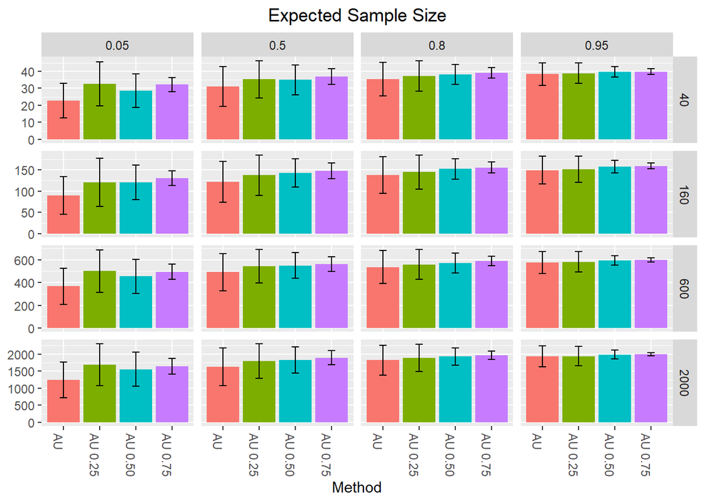

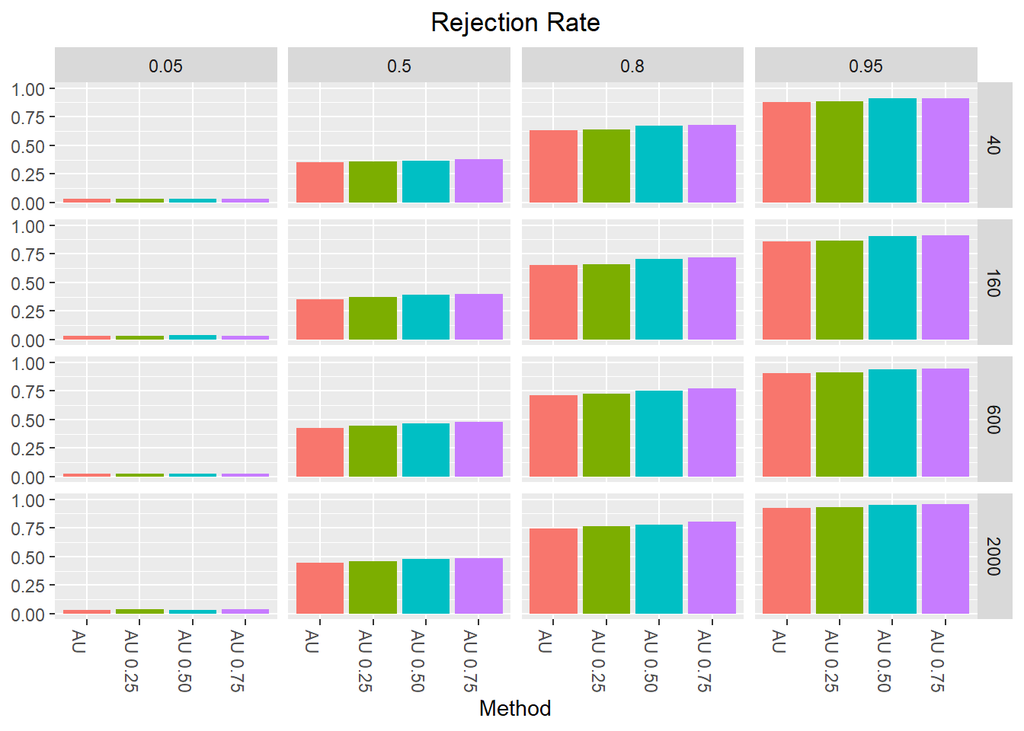

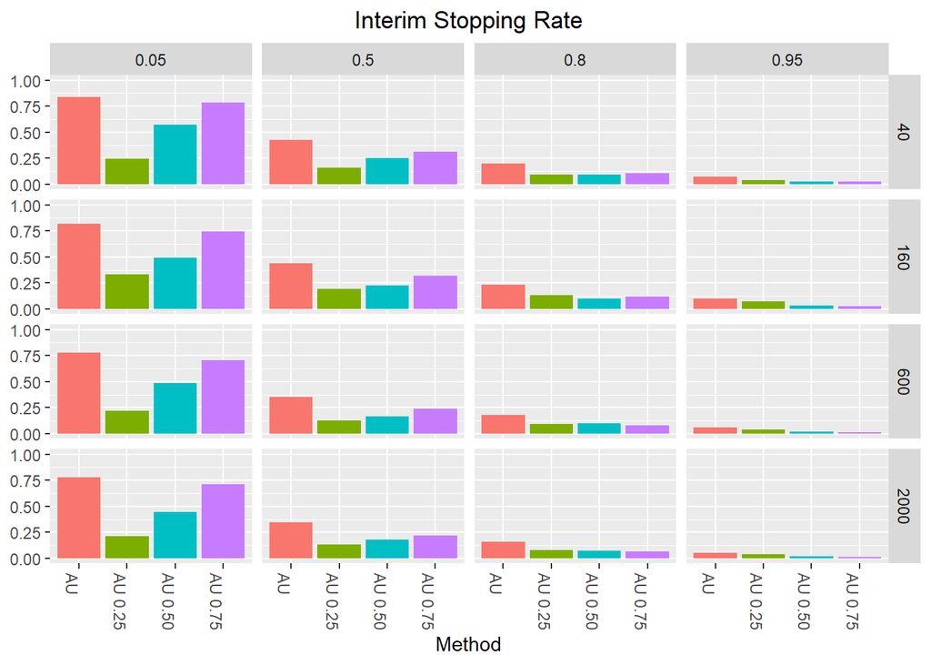

**Figure S1:** AU single stopping point results

## CU Single Stopping Point Data Visualizations

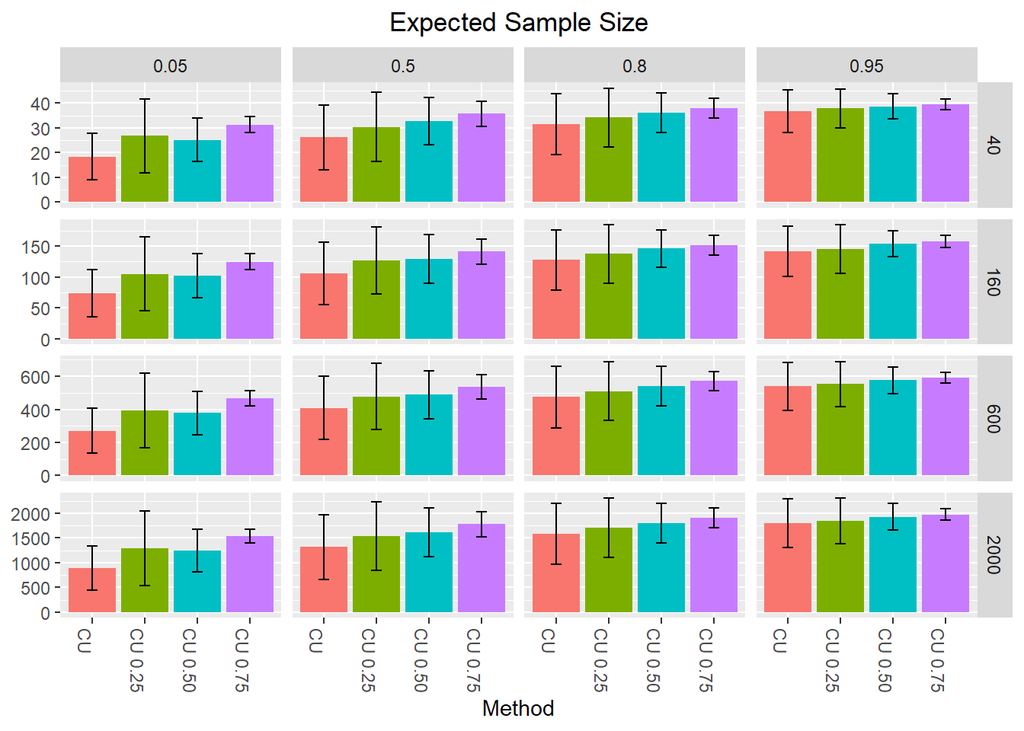

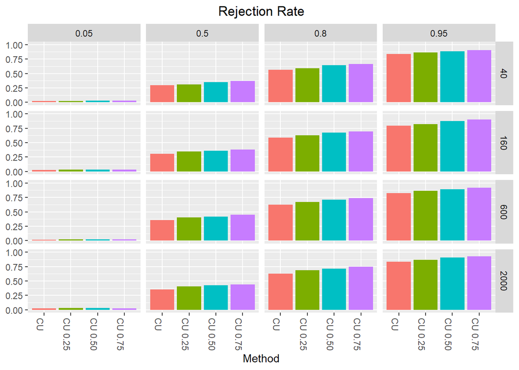

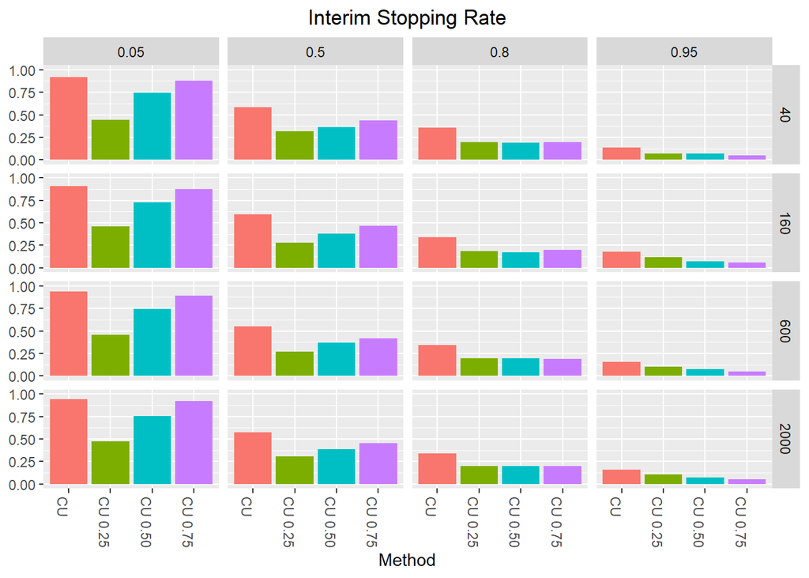

**Figure S2:** CU single stopping point results

## GU Single Stopping Point Data Visualizations

This section includes graphical results summaries comparing between the various versions of group sequential calibrated upstrapping (GU) presented in *Table S9*:*Table S12*. For each sample size ($N$, shown on the y axis) and power ($\beta$, shown on the x axis) based scenario three evaluation metrics are reported: expected total sample size (*Expected Sample Size*), proportion of trials that either stopped early for efficacy or rejected the null hypothesis with the full sample data (*Rejection Rate*), and proportion of trials that stopped early at any interim stopping point (*Interim Stopping Rate*). The *GU* method refers to trials designed with sequential stopping points at 25%, 50%, and 75% of the total sample size. The *GU 0.25* method refers to trials designed with a single interim stopping point at 25% of the total sample size. The *GU 0.50* method refers to trials designed with a single interim stopping point at 50% of the total sample size. The *GU 0.75* method refers to trials designed with a single interim stopping point at 75% of the total sample size.

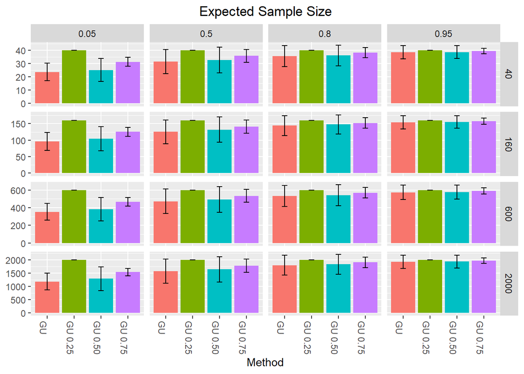

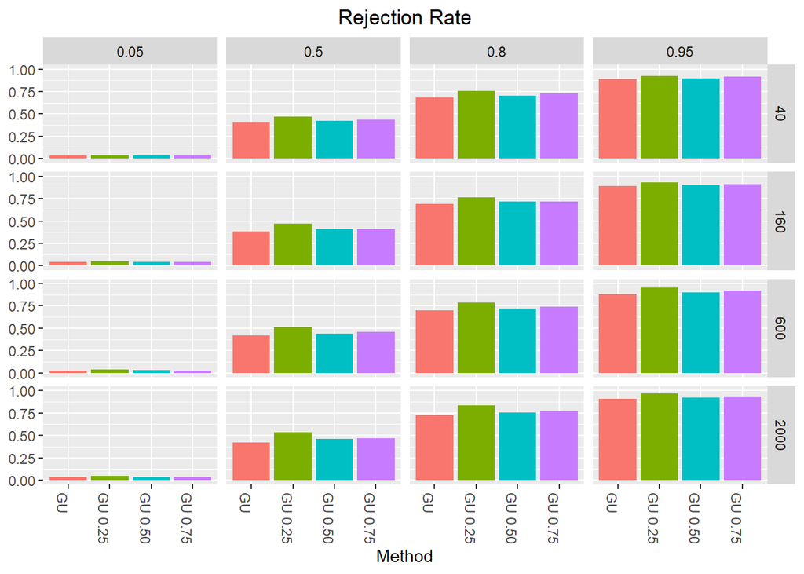

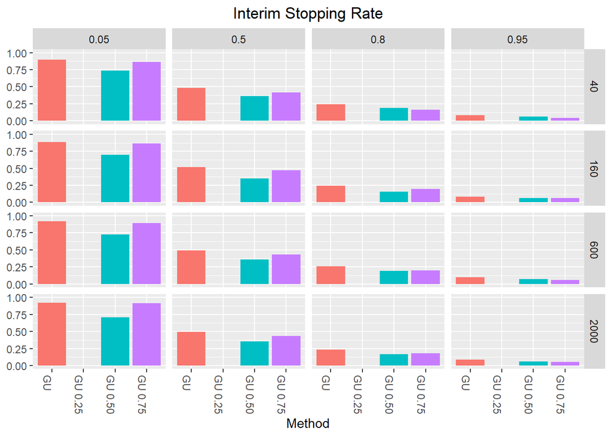

**Figure S3:** GU single stopping point results

## Combined Data Visualizations

This section includes graphical results summaries comparing simultaneously between all the various versions of upstrapping (CU, AU, or GU) presented in *Table S1*:*Table S12*. For each sample size ($N$, shown on the y axis) and power ($\beta$, shown on the x axis) based scenario three evaluation metrics are reported: expected total sample size (*Expected Sample Size*), proportion of trials that either stopped early for efficacy or rejected the null hypothesis with the full sample data (*Rejection Rate*), and proportion of trials that stopped early at any interim stopping point (*Interim Stopping Rate*). The *CU, AU, GU* methods refer to trials designed with sequential stopping points at 25%, 50%, and 75% of the total sample size. The *CU 0.25, AU 0.25, GU 0.25* methods refer to trials designed with a single interim stopping point at 25% of the total sample size. The *CU 0.50, AU 0.50, GU 0.50* methods refer to trials designed with a single interim stopping point at 50% of the total sample size. The *CU 0.75, AU 0.75, GU 0.75* methods refer to trials designed with a single interim stopping point at 75% of the total sample size.

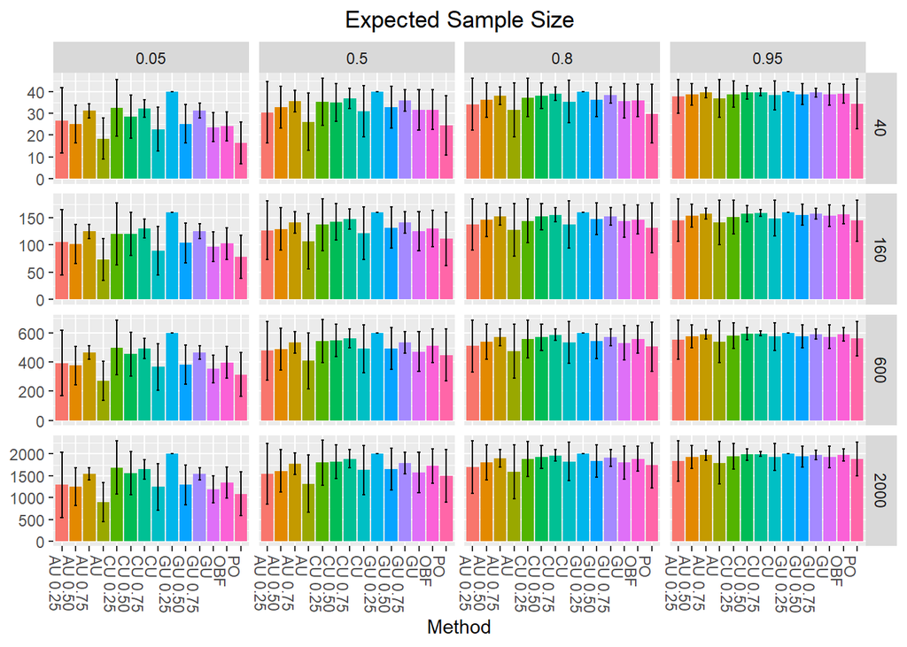

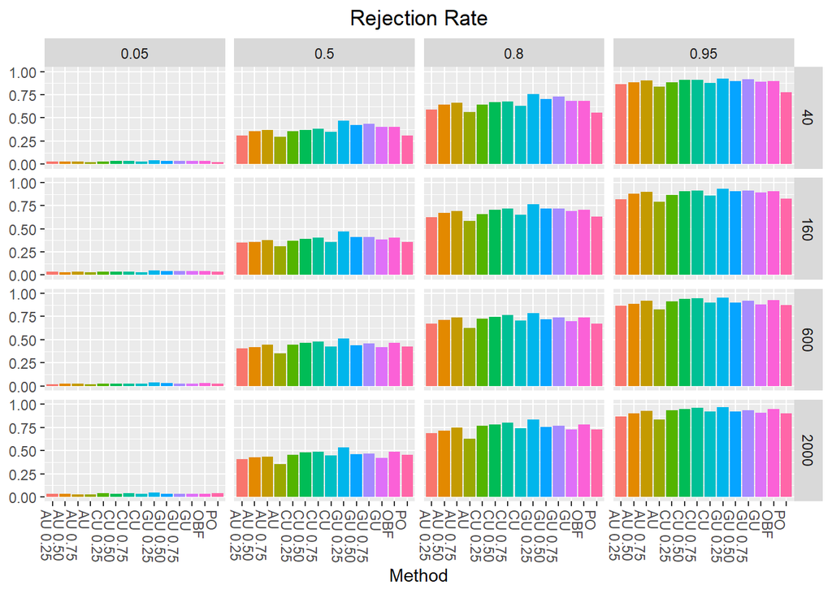

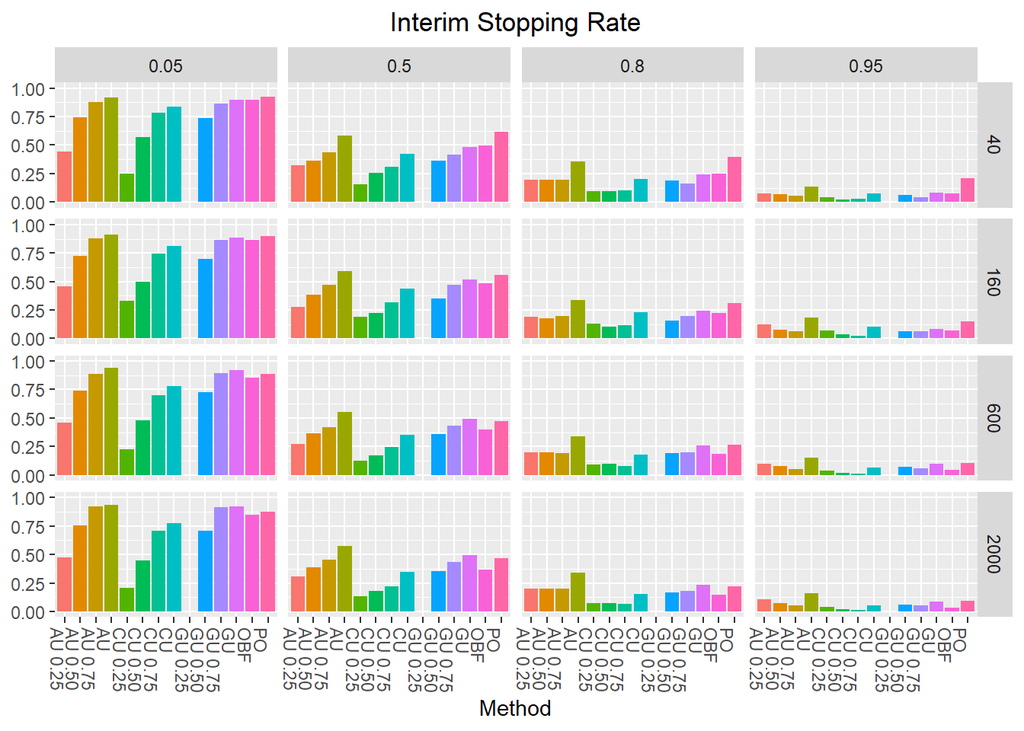

**Figure S4:** Combined results for all methods

## Sensitivity Analysis: Upstrapping Results Excluding the 25% Monitoring Point

Due to concerns that method performance might be inhibited by lack of sufficient data at particularly early monitoring points, simulations dropping the earliest interim analysis (at 25% of the full sample) were implemented. Results from this sensitivity analysis are consistent with the main results findings overall, with small to moderate gains in operating characteristics across methods. Without the possibility of stopping for futility at 25% of the full sample ESS increased for all methods proportionally.

While CP 1% still performs best out of all four CP based methods, the decrease in power under the alternative is lessened compared to the main results findings, with power reductions of up to 1.6% and 7.2% for CP 1% and CP 5% respectively. Type I error rate was consistent with previous results. For ESS the difference between the four CP methods was narrower, ranging from 52-65% of FS under the null and 83-100% under the alternative.

Excluding the first interim look does have a positive effect on performance of the upstrapping based designs. Both AU and CU achieved improvements in power and type I error rate and higher ESS under the alternative scenario. While ESS under the null scenario showed more modest results compared to the main findings, it was still significantly reduced compared to FS. After excluding the first interim look the upstrapping designs were more comparable to both OBF, CP 5%, and CP 1%.

The full results of this sensitivity analysis are shown below in *Table S15* and Figure S5 below.

*Table S15* describes sensitivity analysis results from alternative and null scenario simulations for the performance of the interim analysis calibration method, excluding the first interim monitoring point, relative to the fixed sample design. CU is the calibrated upstrap, AU is the arbitrary upstrap, GU is the group-sequential upstrap, OBF is the O’Brien-Fleming alpha-spending function, PO is the Pocok alpha-spending function, CP is the conditional power method. ESS refers here to expected sample size, while TIE refers to the type I error rate. Any positive increases in TIE and power for GU, OBF, and PO relative to the fixed sample occur because group sequential designs involve an adjusted p-value boundary for the final analysis.

**Table S15: Sensitivity Analysis Results with Two Stopping Points (50% and 75%)**

| Method | N | *Null* Expected N Ratio | *Null* Type I Error Difference | *Alternative* Expected N Ratio | *Alternative* Power Difference |
| --- | --- | --- | --- | --- | --- |
| 0.50-0.75 AU | 40 | 0.68 | 0.000 | 0.95 | -0.016 |
| 0.50-0.75 AU | 160 | 0.68 | -0.002 | 0.94 | -0.020 |
| 0.50-0.75 AU | 600 | 0.69 | -0.004 | 0.94 | -0.026 |
| 0.50-0.75 AU | 2000 | 0.70 | -0.005 | 0.95 | -0.033 |
| 0.50-0.75 CU | 40 | 0.60 | -0.006 | 0.90 | -0.052 |
| 0.50-0.75 CU | 160 | 0.59 | -0.005 | 0.89 | -0.065 |
| 0.50-0.75 CU | 600 | 0.58 | -0.009 | 0.88 | -0.080 |
| 0.50-0.75 CU | 2000 | 0.58 | -0.013 | 0.88 | -0.116 |
| 0.50-0.75 GU | 40 | 0.60 | -0.002 | 0.90 | 0.001 |
| 0.50-0.75 GU | 160 | 0.61 | 0.002 | 0.91 | -0.032 |
| 0.50-0.75 GU | 600 | 0.59 | -0.004 | 0.89 | -0.076 |
| 0.50-0.75 GU | 2000 | 0.59 | -0.008 | 0.90 | -0.083 |
| 0.50-0.75 CP 1% | 40 | 0.65 | -0.013 | 1.00 | -0.002 |
| 0.50-0.75 CP 1% | 160 | 0.63 | -0.020 | 0.96 | -0.008 |
| 0.50-0.75 CP 1% | 600 | 0.63 | -0.012 | 0.96 | -0.008 |
| 0.50-0.75 CP 1% | 2000 | 0.62 | -0.019 | 0.97 | -0.016 |
| 0.50-0.75 CP 5% | 40 | 0.58 | -0.017 | 0.98 | -0.010 |
| 0.50-0.75 CP 5% | 160 | 0.58 | -0.021 | 0.92 | -0.032 |
| 0.50-0.75 CP 5% | 600 | 0.56 | -0.015 | 0.91 | -0.059 |
| 0.50-0.75 CP 5% | 2000 | 0.56 | -0.024 | 0.92 | -0.072 |
| 0.50-0.75 CP 10% | 40 | 0.55 | -0.020 | 0.92 | -0.082 |
| 0.50-0.75 CP 10% | 160 | 0.54 | -0.026 | 0.90 | -0.061 |
| 0.50-0.75 CP 10% | 600 | 0.54 | -0.020 | 0.88 | -0.100 |
| 0.50-0.75 CP 10% | 2000 | 0.54 | -0.029 | 0.88 | -0.123 |
| 0.50-0.75 CP 20% | 40 | 0.55 | -0.024 | 0.88 | -0.119 |
| 0.50-0.75 CP 20% | 160 | 0.52 | -0.031 | 0.84 | -0.140 |
| 0.50-0.75 CP 20% | 600 | 0.52 | -0.024 | 0.83 | -0.181 |
| 0.50-0.75 CP 20% | 2000 | 0.52 | -0.033 | 0.83 | -0.220 |

*Figure S5* describes the results for a sensitivity analysis excluding the first interim monitoring point (i.e. interim analyses are performed at 50% and 75% of the total planned sample). The panels from left to right show mean expected sample size, rejection rate, and interim stopping rate.

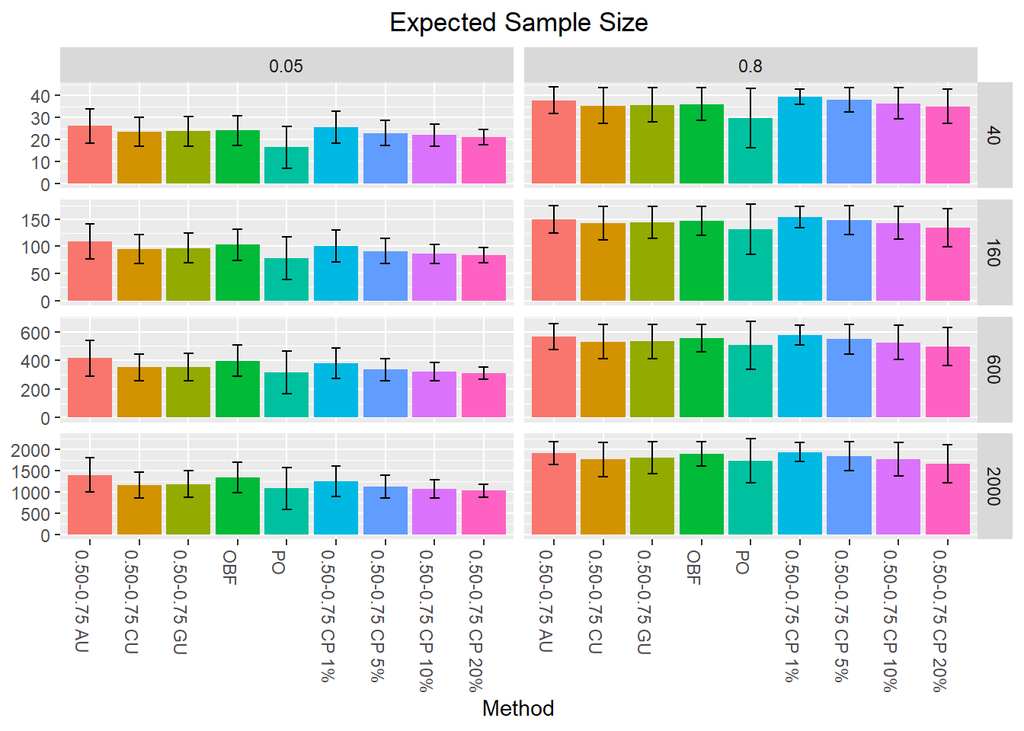

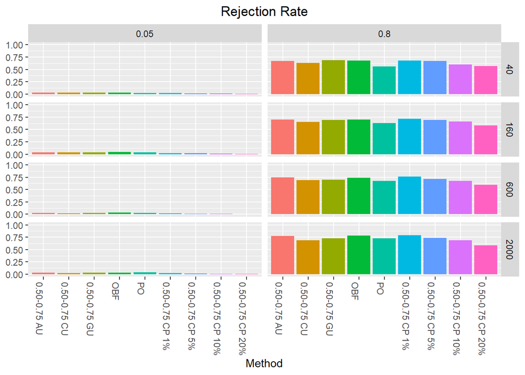

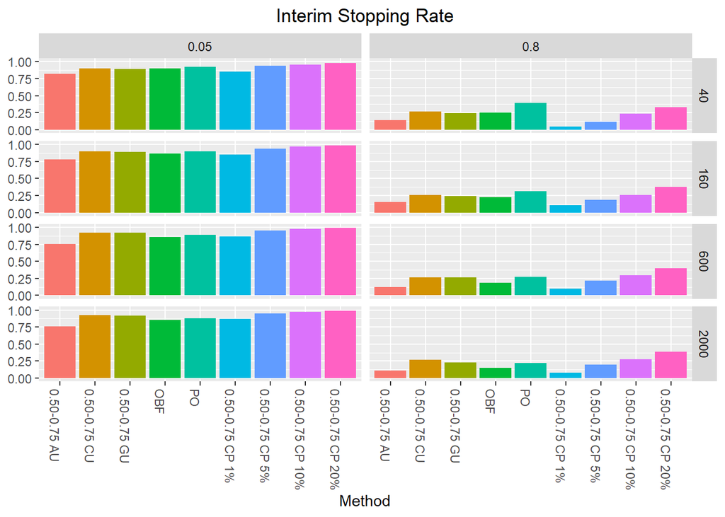

**Figure S5:** Sensitivity Analysis Results